# Adaptive potential Models

# 6 Remove outliers in shift

```r
# LAT
LAT_obs <- mydataset %>%
    filter(Type == "LAT")

summary(LAT_obs$SHIFT_abs)
```

```
##    Min. 1st Qu.  Median    Mean 3rd Qu.    Max.
##  0.0000  0.2697  1.0909  2.4441  3.2061 39.3400
```

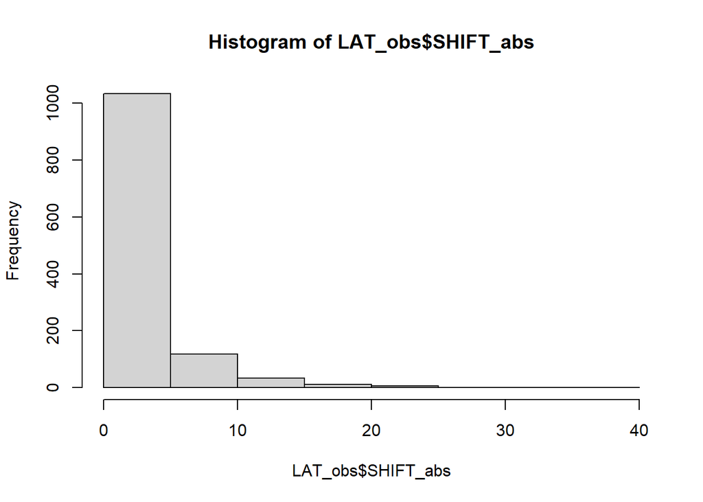

```r
hist(LAT_obs$SHIFT_abs)
```

```r
thr <- quantile(LAT_obs$SHIFT_abs,c(.01,0.99))
thr
```

```
##       1%      99%
##  0.00000 16.39544
```

```r
rem <- which((LAT_obs$SHIFT_abs > thr[1]) & (LAT_obs$SHIFT_abs < thr[2]))
if(any(rem)){
    LAT_obs <- LAT_obs[rem,]
}
summary(LAT_obs$SHIFT_abs)
```

```
##    Min. 1st Qu.  Median    Mean 3rd Qu.    Max.
##  0.0000  0.3533  1.2086  2.3623  3.2602 16.1721
```

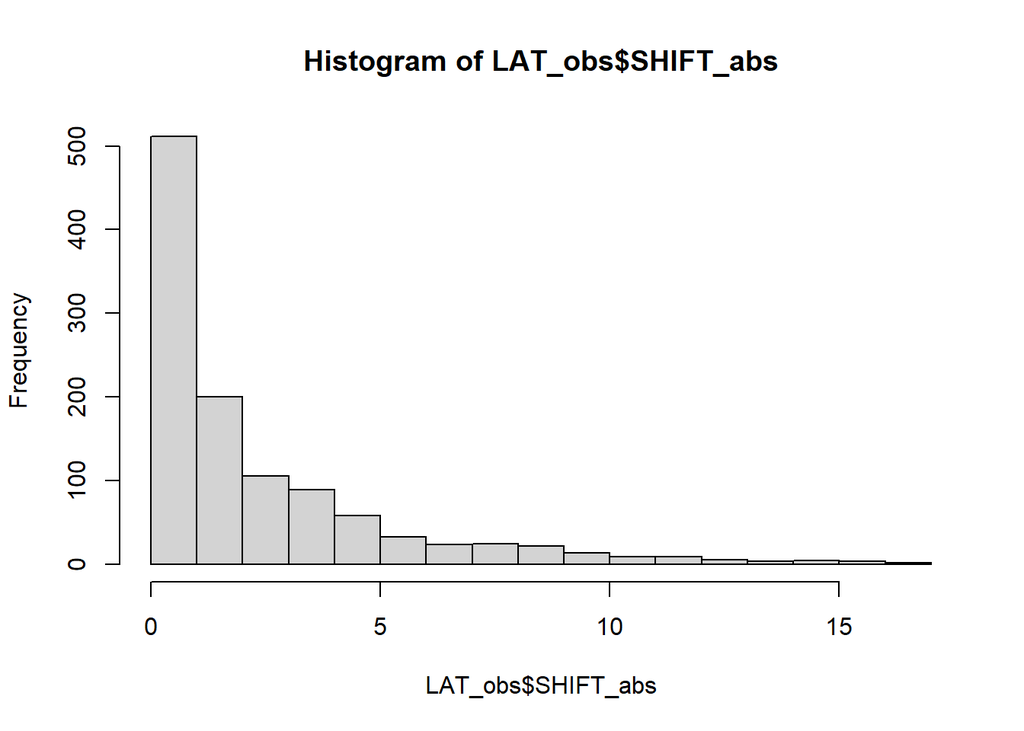

```r
hist(LAT_obs$SHIFT_abs)
```

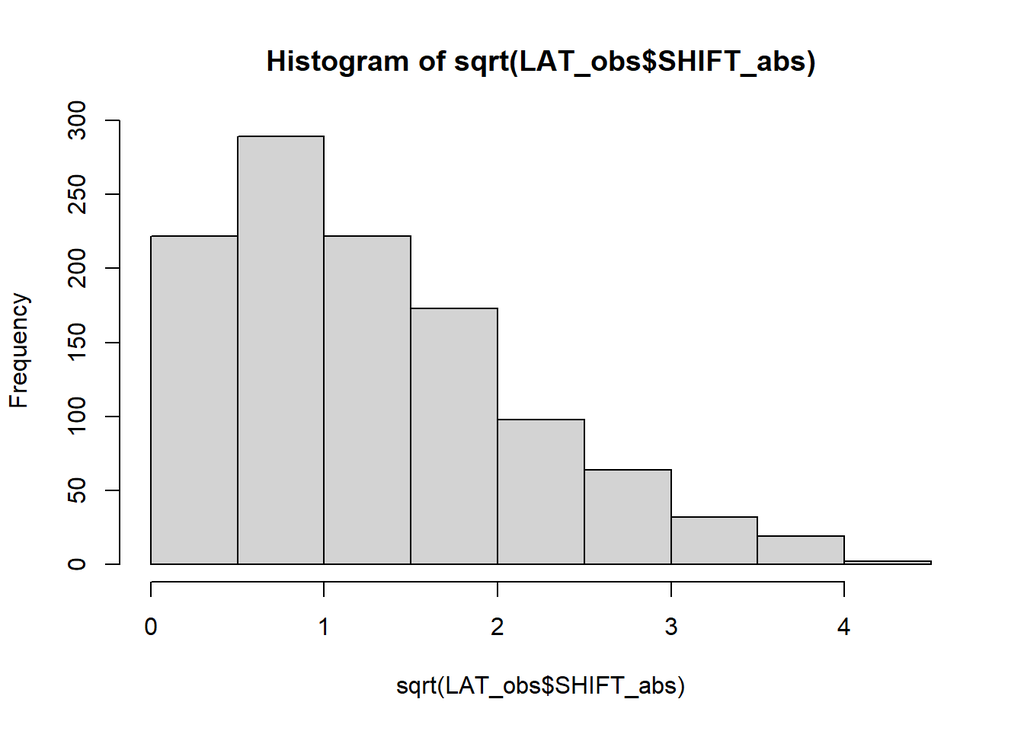

```r
hist(sqrt(LAT_obs$SHIFT_abs))
```

```r
# ELE
ELE_obs <- mydataset %>%
    filter(Type == "ELE")

summary(ELE_obs$SHIFT_abs)
```

```
##     Min.  1st Qu.   Median     Mean  3rd Qu.     Max.
##   0.0000   0.1642   0.8452   2.4913   2.9561 119.1696
```

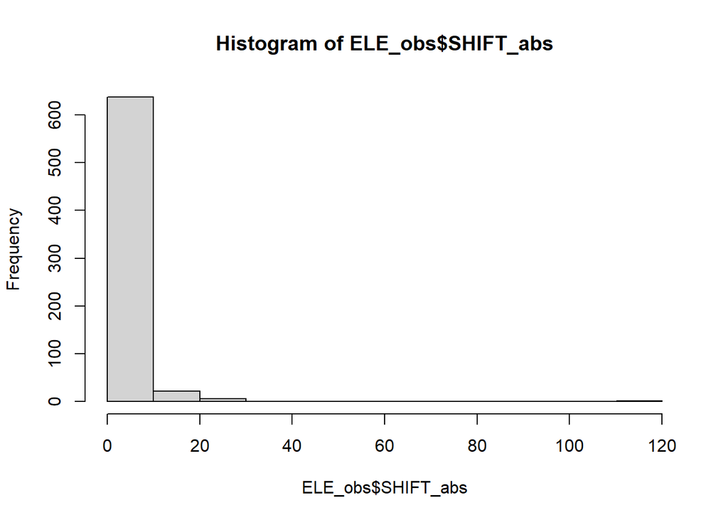

```r
hist(ELE_obs$SHIFT_abs)
```

```r
thr <- quantile(ELE_obs$SHIFT_abs,c(.01,0.99))
thr
```

```
##      1%     99%
##  0.0000 20.4639
```

```r
rem <- which((ELE_obs$SHIFT_abs > thr[1]) & (ELE_obs$SHIFT_abs < thr[2]))
if(any(rem)){
    ELE_obs <- ELE_obs[rem,]
}
summary(ELE_obs$SHIFT_abs)
```

```
##     Min.  1st Qu.   Median     Mean  3rd Qu.     Max.
##  0.01315  0.51587  1.26564  2.55395  3.43961 19.21396
```

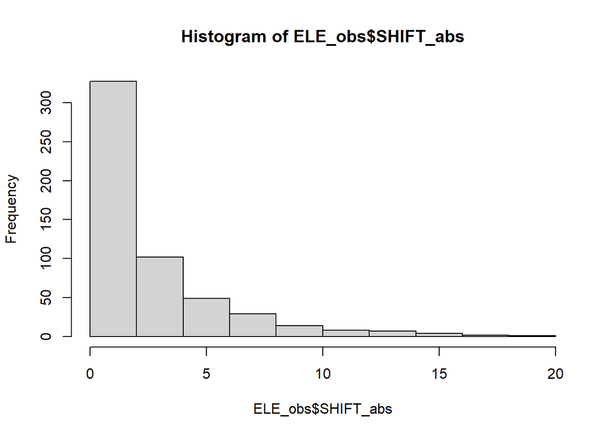

```r
hist(ELE_obs$SHIFT_abs)
```

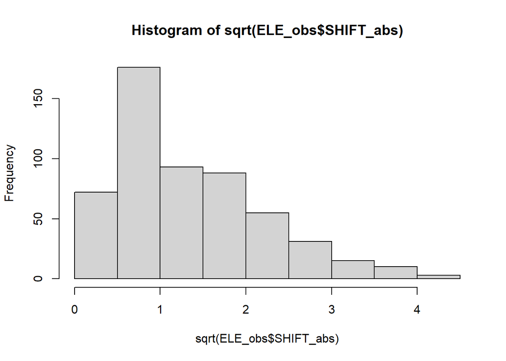

```r
hist(sqrt(ELE_obs$SHIFT_abs))
```

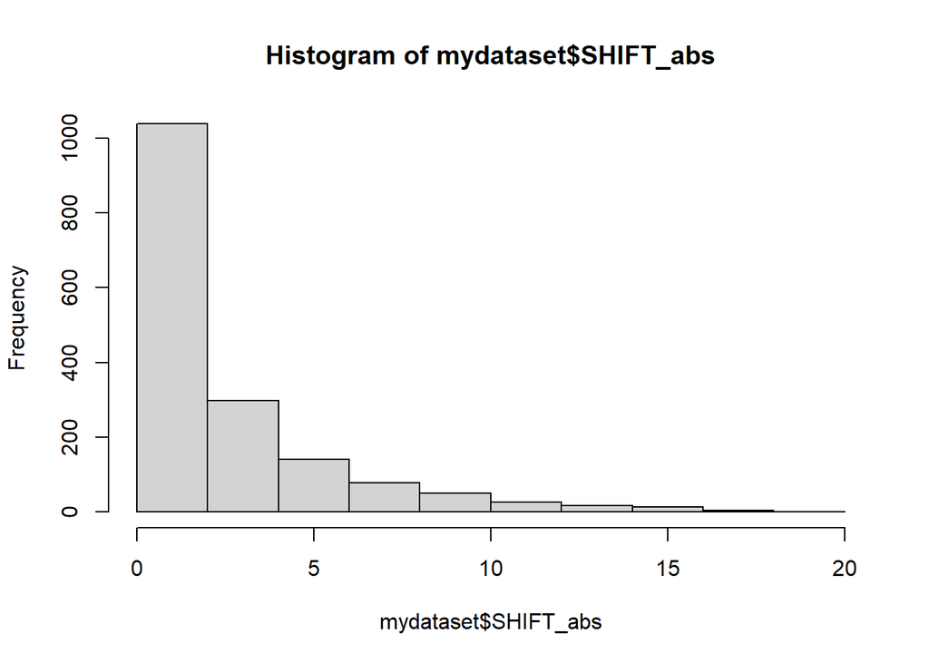

```r
# Combine
mydataset <- rbind(LAT_obs,ELE_obs)
hist(mydataset$SHIFT_abs)
```

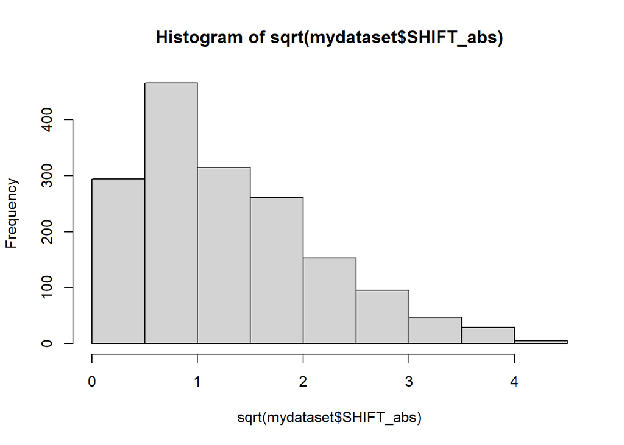

```r
hist(sqrt(mydataset$SHIFT_abs))
```

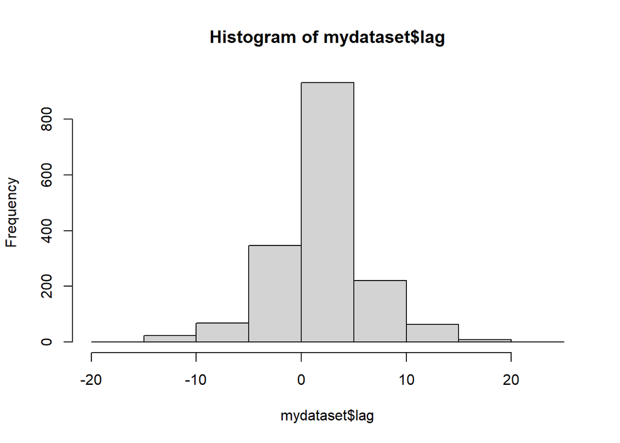

```r
##############
# Lags look ok

# remove outliers in lag
# summary(mydataset$lag)
hist(mydataset$lag)
```

```r
# thr <- quantile(mydataset$lag,c(.01,0.99))
# thr
#
# rem <- which((mydataset$lag > thr[1]) & (mydataset$lag < thr[2]))
# if(any(rem)){
#     mydataset <- mydataset[rem,]
# }
# summary(mydataset$lag)
# hist(mydataset$lag)
```

# 7 Playing with models

## 7.1 Latitude

```r
mydatatogo <- mydataset  %>%
    dplyr::filter(Type == "LAT") %>%
    mutate(He_harm = scale(He_harm),
           He_harm2 = scale(He_harm2),
           He_harm3 = scale(He_harm3),
           # He_harm_w = scale(He_harm),
           # He_harm2_w = scale(He_harm2_w),
           # He_harm3_w = scale(He_harm3_w),
           velocity_raw = velocity,
           velocity = scale(velocity_raw),
           velocity_abs = scale(abs(velocity_raw)),
           lag = scale(lag),
           lag2 = scale(lag2),
           lagC = scale(lagC),
           lagC2 = scale(lagC2),
           lagC3 = lagC3,
           ID.area = scale(ID.area),
           DUR = scale(DUR),
           dist_weight = 1/log(min_dist), # this is the transformation I found leads to a normal distribution
           START = scale(START),
           SHIFT_raw = SHIFT,
           SHIFT = scale(SHIFT_raw),
           SHIFT_abs =
               # scale(sqrt(
               SHIFT_abs
           # ))
           ,
           SHIFT_cor_raw = scale(SHIFT_cor),
           SHIFT_cor = scale(SHIFT_cor_raw),
           SHIFT_cor_abs = scale(sqrt(abs(SHIFT_cor))),
           Param = factor(Param),
           Group = factor(Group),
           spp = factor(spp)) %>%
    dplyr::select(He_harm, He_harm2, He_harm3,
                  # He_harm_w, He_harm2_w, He_harm3_w,
                  lag, lag2, lag3, lagC, lagC2, lagC3,
                  SHIFT, SHIFT_abs, SHIFT_cor, SHIFT_cor_abs, SHIFT_raw, SHIFT_cor_raw,
                  Param, Group, spp, Class, Family, Genus, velocity, velocity_abs, velocity_raw,
                  START, DUR, Uncertainty_Parameter, Uncertainty_Distribution, Grain_size, Data, ID.area, Sampling, Article_ID,
                  min_dist, dist_weight,
                  Marker,
                  shift_vel_sign)

mydatatogo <- data.frame(mydatatogo)
dim(mydatatogo)
```

```
## [1] 1121   37
```

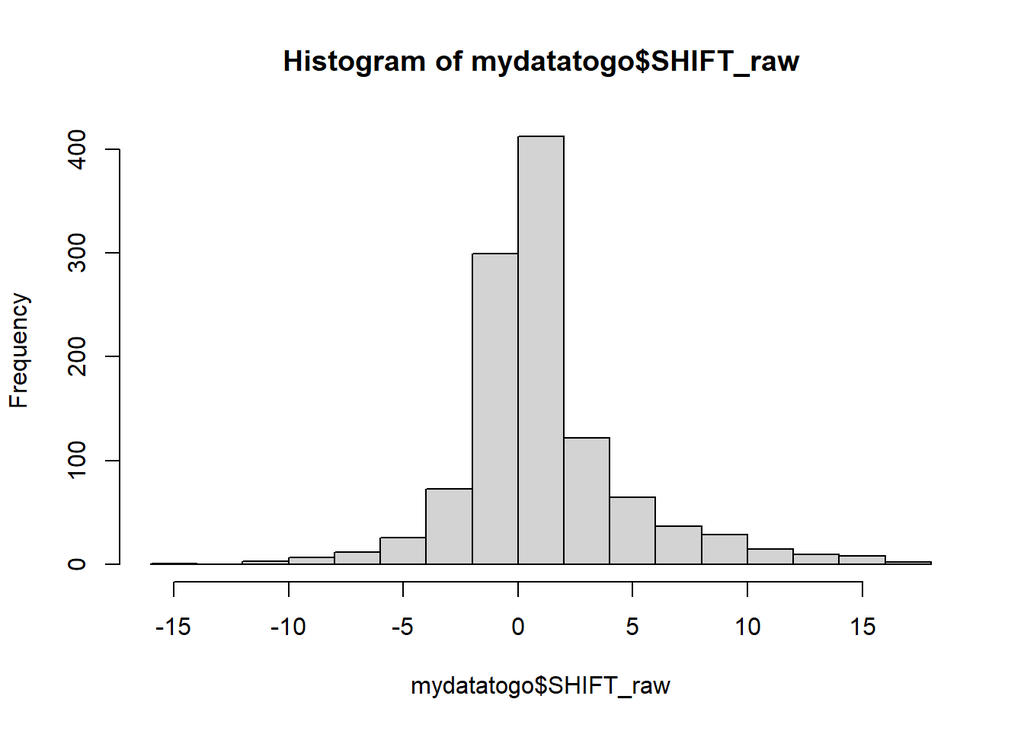

```r
hist(mydatatogo$SHIFT_raw)
```

```r
model_data = mydatatogo

# define the He metric to go
model_data$He <- as.numeric(model_data$He_harm)
# define the shift metric to go
model_data$SHIFT <- as.numeric(model_data$SHIFT_abs)

bestmodel <- glmmTMB(SHIFT_abs ~
                         # Fixed effects
                         ## Ecology
                         velocity_abs*He*Param +
                         ## Control Methods
                         # START + ID.area + Sampling + Uncertainty_Parameter +
                         # Uncertainty_Distribution + Grain_size + Data +
                         # Random effects
                         ## Studies
                         (1|Article_ID)+
                         ## Taxonomy
                         (1|spp),
                     # weight by distance of genetic data to range shift data
                     # weights = 1/(min_dist),
                     family = Gamma(link = "log"),
                     data = model_data,
                     na.action = "na.fail")

baseline <- glmmTMB(SHIFT_abs ~
                        # Fixed effects
                        ## Ecology
                        velocity_abs*Param +
                        ## Control Methods
                        # START + ID.area + Sampling + Uncertainty_Parameter +
                        # Uncertainty_Distribution + Grain_size + Data +
                        # Random effects
                        ## Studies
                        (1|Article_ID)+
                        ## Taxonomy
                        (1|spp),
                    # weight by distance of genetic data to range shift data
                    # weights = dist_weight,
                    family = Gamma(link = "log"),
                    data = model_data,
                    na.action = "na.fail")


AIC(bestmodel,baseline)
```

```
##           df      AIC
## bestmodel 15 3524.018
## baseline   9 3518.751
```

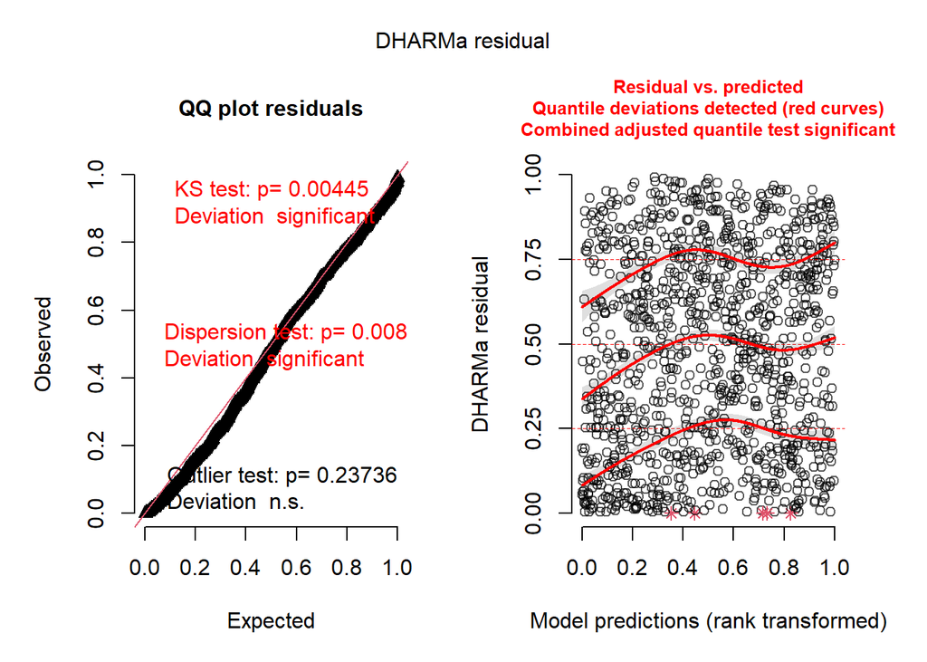

```r
plot(simulateResiduals(bestmodel))
```

```r
summary(bestmodel)
```

```
##  Family: Gamma  ( log )
## Formula:
## SHIFT_abs ~ velocity_abs * He * Param + (1 | Article_ID) + (1 |      spp)
## Data: model_data
##
##      AIC      BIC   logLik deviance df.resid
##   3524.0   3599.3  -1747.0   3494.0     1106
##
## Random effects:
##
## Conditional model:
##  Groups     Name        Variance Std.Dev.
##  Article_ID (Intercept) 0.6434   0.8022
##  spp        (Intercept) 0.1960   0.4427
## Number of obs: 1121, groups:  Article_ID, 60; spp, 234
##
## Dispersion estimate for Gamma family (sigma^2): 1.01
##
## Conditional model:
##                         Estimate Std. Error z value Pr(>|z|)
## (Intercept)              0.87793    0.14958   5.869 4.38e-09 ***
## velocity_abs            -0.02304    0.11546  -0.200  0.84183
## He                      -0.02342    0.08943  -0.262  0.79338
## ParamO                  -0.22645    0.10482  -2.160  0.03075 *
## ParamTE                 -0.43471    0.15068  -2.885  0.00392 **
## velocity_abs:He          0.07772    0.09017   0.862  0.38872
## velocity_abs:ParamO      0.18342    0.10575   1.734  0.08284 .
## velocity_abs:ParamTE     0.35353    0.14205   2.489  0.01282 *
## He:ParamO               -0.02050    0.09286  -0.221  0.82528
## He:ParamTE               0.17700    0.13311   1.330  0.18359
## velocity_abs:He:ParamO  -0.08150    0.09743  -0.837  0.40287
## velocity_abs:He:ParamTE -0.22166    0.12238  -1.811  0.07011 .
## ---
## Signif. codes:  0 '***' 0.001 '**' 0.01 '*' 0.05 '.' 0.1 ' ' 1
```

```r
tmp <- effects::allEffects(bestmodel)
```

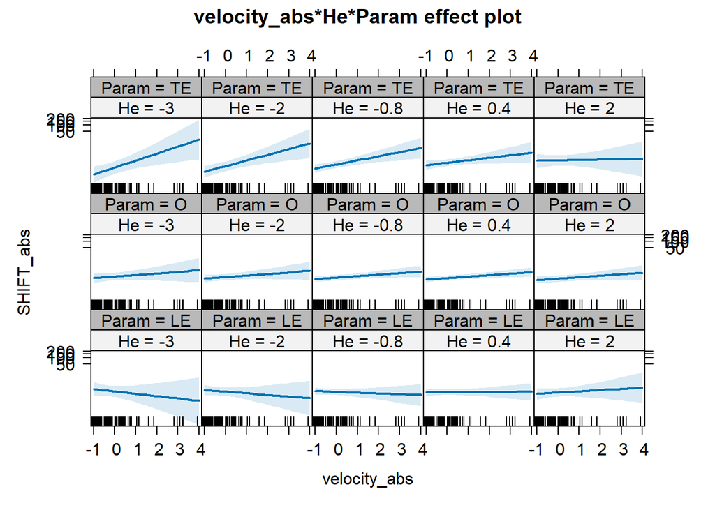

```r
plot(tmp$`velocity_abs:He:Param`)
```

### 7.1.1 Shift model Param

```r
model_data = mydatatogo

# define the He metric to go
model_data$He <- as.numeric(model_data$He_harm2)

bestmodel <- lmer(SHIFT ~
                      # Fixed effects
                      ## Ecology
                      velocity*He*Param +
                      ## Control Methods
                      # START + ID.area + Sampling + Uncertainty_Parameter +
                      # Uncertainty_Distribution + Grain_size + Data +
                      # Random effects
                      ## Studies
                      (1|Article_ID)+
                      ## Taxonomy
                      (1|spp),
                  # weight by distance of genetic data to range shift data
                  # weights = dist_weight,
                  data = model_data,
                  na.action = "na.fail")

baseline <- lmer(SHIFT ~
                     # Fixed effects
                     ## Ecology
                     velocity*Param +
                     ## Control Methods
                     START + ID.area + Sampling + Uncertainty_Parameter +
                     Uncertainty_Distribution + Grain_size + Data +
                     # Random effects
                     ## Studies
                     (1|Article_ID)+
                     ## Taxonomy
                     (1|spp),
                 # weight by distance of genetic data to range shift data
                 # weights = dist_weight,
                 REML=TRUE,
                 data = model_data,
                 na.action = "na.fail")
```

```
## boundary (singular) fit: see help('isSingular')
```

```r
AIC(bestmodel,baseline)
```

```
##           df      AIC
## bestmodel 15 3197.867
## baseline  18 3190.164
```

```r
tmp <- effects::allEffects(bestmodel)
```

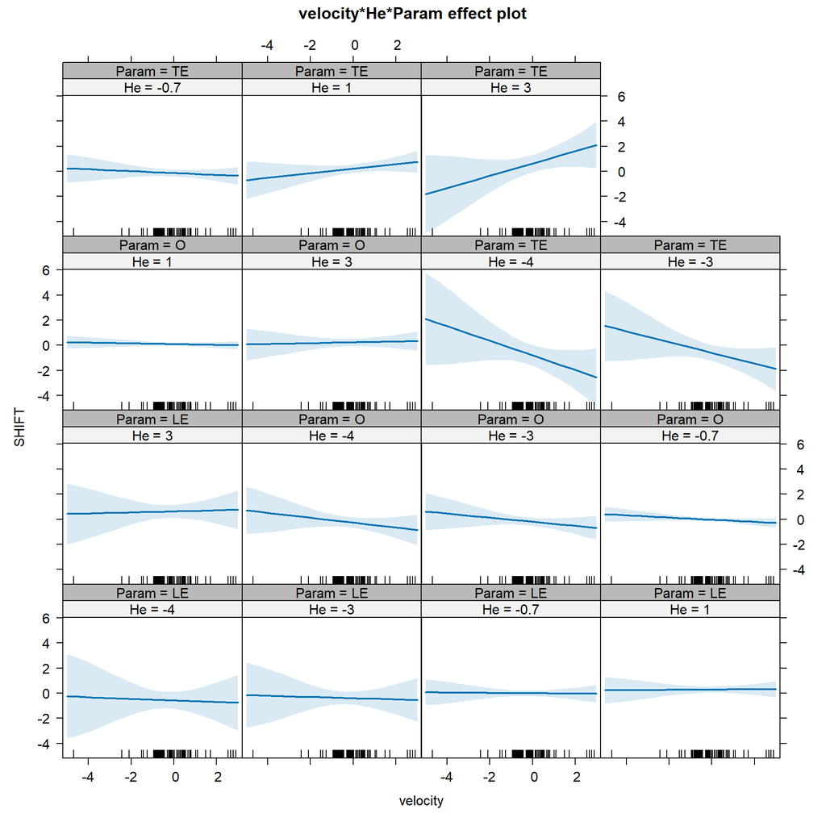

```r
plot(tmp$`velocity:He:Param`)
```

```r
summary(bestmodel)
```

```
## Linear mixed model fit by REML ['lmerMod']
## Formula: SHIFT ~ velocity * He * Param + (1 | Article_ID) + (1 | spp)
##    Data: model_data
##
## REML criterion at convergence: 3167.9
##
## Scaled residuals:
##     Min      1Q  Median      3Q     Max
## -4.0683 -0.3910 -0.0790  0.2546  4.2251
##
## Random effects:
##  Groups     Name        Variance Std.Dev.
##  spp        (Intercept) 0.10645  0.3263
##  Article_ID (Intercept) 0.04501  0.2121
##  Residual               0.85811  0.9263
## Number of obs: 1121, groups:  spp, 234; Article_ID, 60
##
## Fixed effects:
##                      Estimate Std. Error t value
## (Intercept)          0.116798   0.084135   1.388
## velocity            -0.003228   0.082025  -0.039
## He                   0.170787   0.073556   2.322
## ParamO              -0.096616   0.082982  -1.164
## ParamTE             -0.102204   0.121739  -0.840
## velocity:He          0.014846   0.081373   0.182
## velocity:ParamO     -0.061317   0.085442  -0.718
## velocity:ParamTE     0.034219   0.115820   0.295
## He:ParamO           -0.098501   0.077886  -1.265
## He:ParamTE           0.032907   0.112967   0.291
## velocity:He:ParamO   0.017765   0.089934   0.198
## velocity:He:ParamTE  0.138234   0.119874   1.153
##
## Correlation of Fixed Effects:
##             (Intr) velcty He     ParamO ParmTE vlct:H vlc:PO vl:PTE H:PrmO
## velocity     0.050
## He           0.031 -0.119
## ParamO      -0.751 -0.033 -0.035
## ParamTE     -0.458 -0.039 -0.020  0.444
## velocity:He -0.115 -0.165  0.139  0.108  0.108
## velcty:PrmO -0.037 -0.881  0.118  0.021  0.034  0.148
## vlcty:PrmTE -0.033 -0.523  0.097  0.021 -0.050  0.104  0.497
## He:ParamO   -0.035  0.107 -0.832  0.023  0.013 -0.131 -0.124 -0.090
## He:ParamTE  -0.023  0.071 -0.555  0.015  0.102 -0.116 -0.068 -0.106  0.516
## vlcty:H:PrO  0.093  0.126 -0.127 -0.115 -0.092 -0.874 -0.187 -0.091  0.138
## vlcty:H:PTE  0.071  0.090 -0.126 -0.070 -0.113 -0.646 -0.091  0.028  0.098
##             H:PrTE v:H:PO
## velocity
## He
## ParamO
## ParamTE
## velocity:He
## velcty:PrmO
## vlcty:PrmTE
## He:ParamO
## He:ParamTE
## vlcty:H:PrO  0.092
## vlcty:H:PTE  0.089  0.581
```

### 7.1.2 Code exp/cont I

This makes all shifts positives and changes the sign of velocity when the raw shift is negative.

```r
# Code expansion vs contraction
mydatatogo$Exp_Cont <- NA
mydatatogo$Exp_Cont[which(mydatatogo$Param == "LE" & mydatatogo$SHIFT_raw <= 0)] <- "Cont"
mydatatogo$Exp_Cont[which(mydatatogo$Param == "LE" & mydatatogo$SHIFT_raw > 0)] <- "Exp"

mydatatogo$Exp_Cont[which(mydatatogo$Param == "TE" & mydatatogo$SHIFT_raw < 0)] <- "Exp"
mydatatogo$Exp_Cont[which(mydatatogo$Param == "TE" & mydatatogo$SHIFT_raw >= 0)] <- "Cont"

mydatatogo$Exp_Cont[
    which(mydatatogo$Param == "O" &
              (mydatatogo$shift_vel_sign == "pospos"  |
                   mydatatogo$shift_vel_sign == "negneg"))] <- "Exp"
mydatatogo$Exp_Cont[
    which(mydatatogo$Param == "O" &
              (mydatatogo$shift_vel_sign == "posneg"  |
                   mydatatogo$shift_vel_sign == "negpos"))] <- "Cont"

table(mydatatogo$Exp_Cont)
```

```
##
## Cont  Exp
##  457  664
```

```r
any(is.na(mydatatogo$shift_vel_sign))
```

```
## [1] FALSE
```

```r
summary(mydatatogo$velocity_raw[which(mydatatogo$shift_vel_sign=="pospos")])
```

```
##     Min.  1st Qu.   Median     Mean  3rd Qu.     Max.
## 0.009396 0.809005 1.477767 1.756996 2.158332 6.929532
```

```r
summary(mydatatogo$velocity_raw[which(mydatatogo$shift_vel_sign=="negneg")])
```

```
##    Min. 1st Qu.  Median    Mean 3rd Qu.    Max.
## -2.3049 -2.3049 -1.7800 -1.4474 -0.4707 -0.4707
```

```r
summary(mydatatogo$SHIFT_raw[which(mydatatogo$shift_vel_sign=="pospos")])
```

```
##    Min. 1st Qu.  Median    Mean 3rd Qu.    Max.
##  0.0000  0.3789  1.3800  2.5953  3.6634 16.0211
```

```r
summary(mydatatogo$SHIFT_raw[which(mydatatogo$shift_vel_sign=="negneg")])
```

```
##    Min. 1st Qu.  Median    Mean 3rd Qu.    Max.
## -4.8937 -2.8379 -1.1292 -1.7454 -0.4374 -0.3000
```

```r
summary(mydatatogo$velocity_raw[which(mydatatogo$SHIFT_raw>0)])
```

```
##    Min. 1st Qu.  Median    Mean 3rd Qu.    Max.
## -5.8328  0.5551  1.3447  1.5189  2.0885  6.9295
```

```r
summary(mydatatogo$velocity_raw[which(mydatatogo$SHIFT_raw<0)])
```

```
##    Min. 1st Qu.  Median    Mean 3rd Qu.    Max.
##  -2.305   0.633   1.177   1.431   2.133   6.930
```

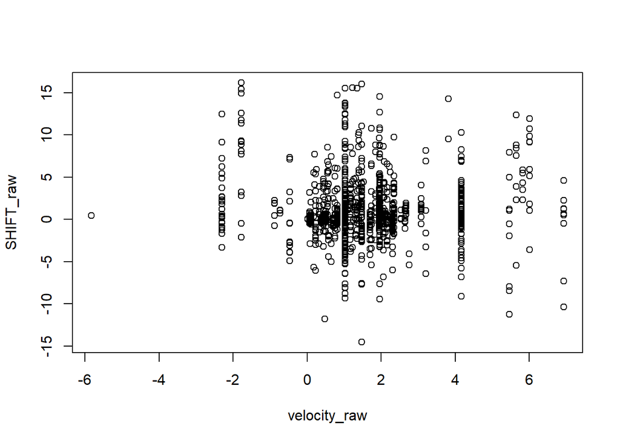

```r
plot(SHIFT_raw~velocity_raw,mydatatogo)
```

```r
# Fix shift & velocity sign
mydatatogo$SHIFTnew <- mydatatogo$SHIFT_raw
# mydatatogo$SHIFTnew <- mydatatogo$SHIFT_cor_raw
mydatatogo$velocitynew <- mydatatogo$velocity_raw

pos <- which(mydatatogo$Param == "LE" & mydatatogo$SHIFT_raw <= 0)
mydatatogo$SHIFTnew[pos] <- mydatatogo$SHIFT_raw[pos] * -1
mydatatogo$velocitynew[pos] <- mydatatogo$velocity_raw[pos] * -1

pos <- which(mydatatogo$Param == "TE" & mydatatogo$SHIFT_raw <= 0)
mydatatogo$SHIFTnew[pos] <- mydatatogo$SHIFT_raw[pos] * -1
mydatatogo$velocitynew[pos] <- mydatatogo$velocity_raw[pos] * -1

pos <- which(mydatatogo$Param == "O" & mydatatogo$SHIFT_raw <= 0)
mydatatogo$SHIFTnew[pos] <- mydatatogo$SHIFT_raw[pos] * -1
mydatatogo$velocitynew[pos] <- mydatatogo$velocity_raw[pos] * -1

summary(mydatatogo$SHIFTnew)
```

```
##    Min. 1st Qu.  Median    Mean 3rd Qu.    Max.
##  0.0000  0.3533  1.2086  2.3623  3.2602 16.1721
```

```r
summary(mydatatogo$velocitynew)
```

```
##    Min. 1st Qu.  Median    Mean 3rd Qu.    Max.
## -6.9295 -1.0197  0.4959  0.4136  1.9452  6.9295
```

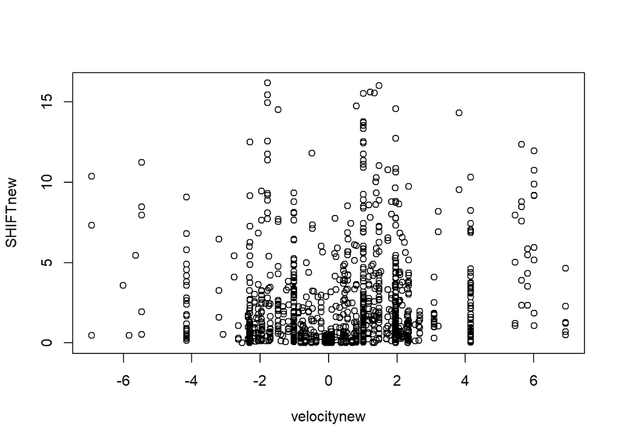

```r
plot(SHIFTnew~velocitynew,mydatatogo)
```

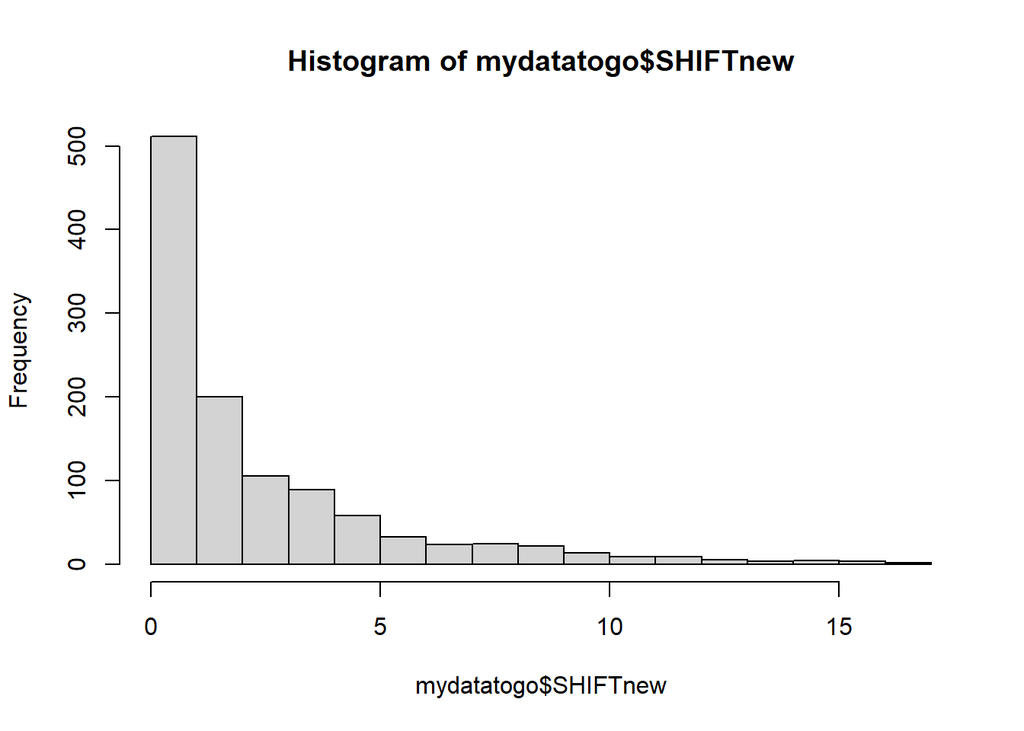

```r
hist(mydatatogo$SHIFTnew)
```

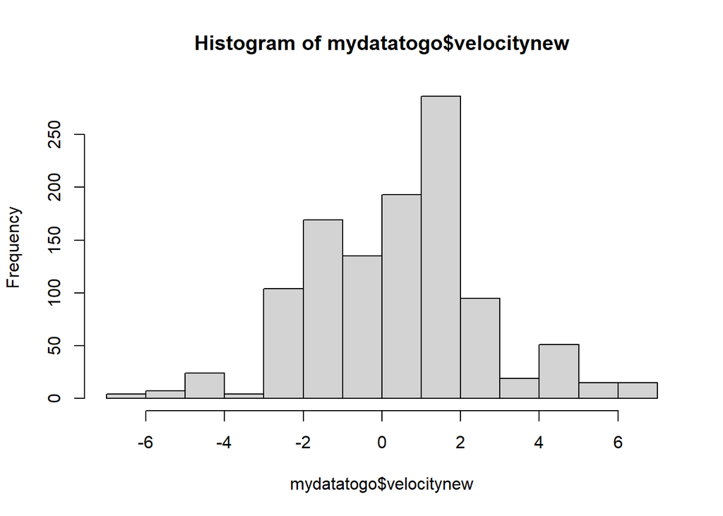

```r
hist(mydatatogo$velocitynew)
```

```r
dim(mydatatogo)
```

```
## [1] 1121   40
```

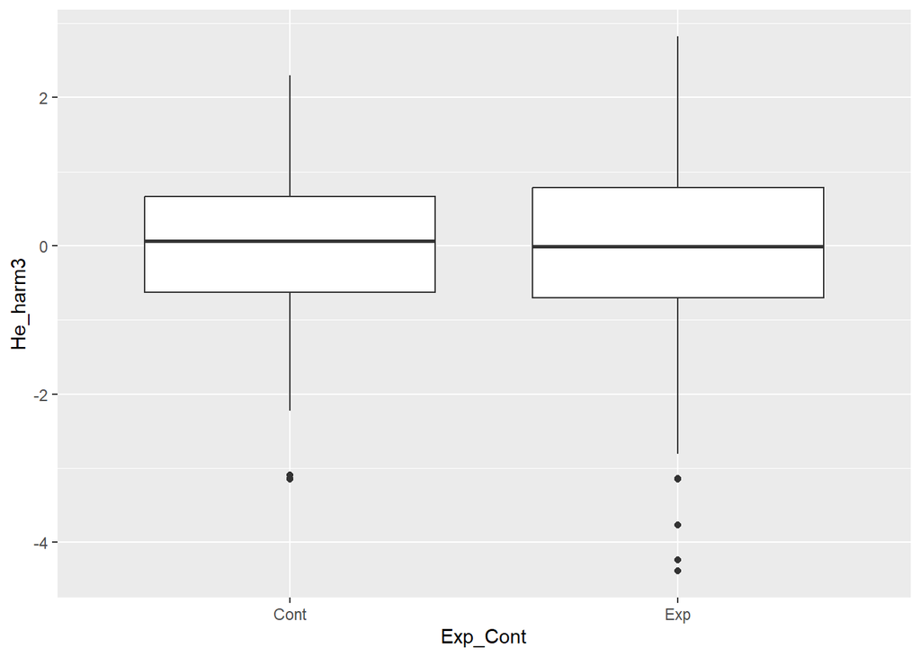

```r
ggplot(mydatatogo, aes(x = Exp_Cont, y = He_harm3))+
    geom_boxplot()
```

```r
mod1 <- aov(He_harm3 ~ Exp_Cont, mydatatogo)
summary(mod1)
```

```
##               Df Sum Sq Mean Sq F value Pr(>F)
## Exp_Cont       1    0.2  0.1564   0.156  0.693
## Residuals   1119 1119.8  1.0008
```

#### 7.1.2.1 Shift model Exp/Cont I

```r
model_data = mydatatogo

# define the He metric to go
model_data$He <- as.numeric(model_data$He_harm2)
# define the lag metric to go
model_data$SHIFT <- as.numeric(model_data$SHIFTnew)
model_data$velocity <- as.numeric(model_data$velocitynew)
model_data$Exp_Cont <- factor(model_data$Exp_Cont)

bestmodel <- glmmTMB(SHIFT ~
                         # Fixed effects
                         ## Ecology
                         velocity*He*Exp_Cont +
                         ## Control Methods
                         START + ID.area + Sampling + Uncertainty_Parameter +
                         Uncertainty_Distribution + Grain_size + Data +
                        # Random effects
                        ## Studies
                        (1|Article_ID)+
                        ## Taxonomy
                        (1|Group),
                    # weight by distance of genetic data to range shift data
                    # weights = dist_weight,
                    family = Gamma(link = "log"),
                    data = model_data,
                    na.action = "na.fail")

baseline <- glmmTMB(SHIFT ~
                        # Fixed effects
                        ## Ecology
                        velocity*Exp_Cont +
                         ## Control Methods
                         START + ID.area + Sampling + Uncertainty_Parameter +
                         Uncertainty_Distribution + Grain_size + Data +
                        # Random effects
                        ## Studies
                        (1|Article_ID)+
                        ## Taxonomy
                        (1|Group),
                    # weight by distance of genetic data to range shift data
                    # weights = dist_weight,
                    family = Gamma(link = "logit"),
                    data = model_data,
                    na.action = "na.fail")
AIC(bestmodel,baseline)
```

```
##           df      AIC
## bestmodel 20 3521.929
## baseline  16 4471.053
```

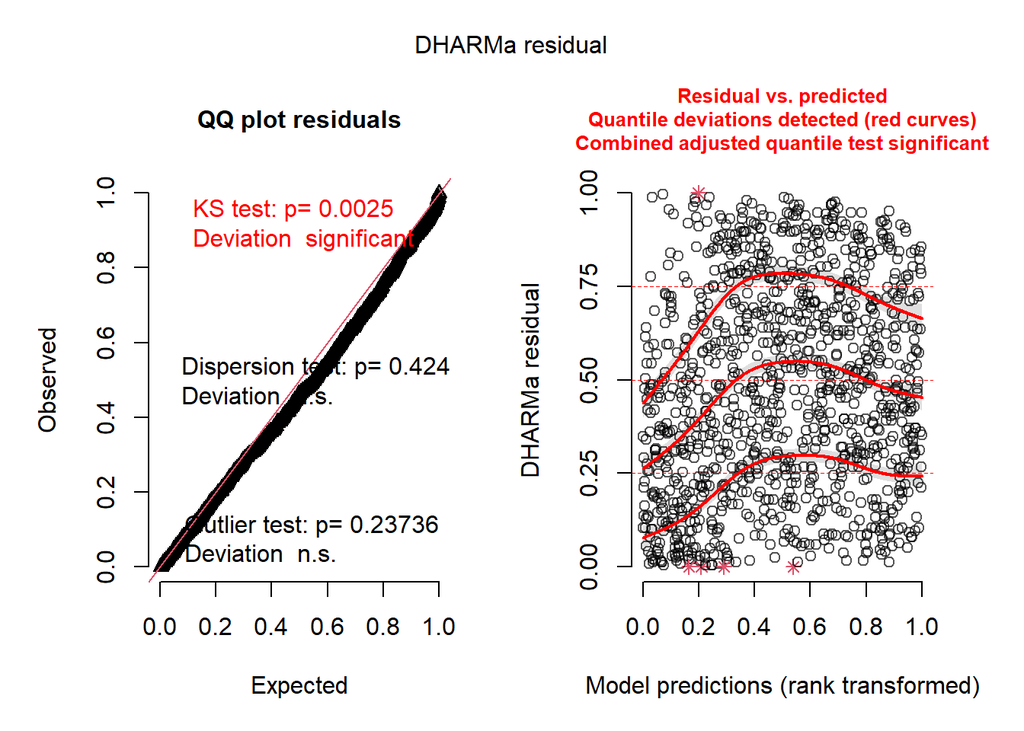

```r
plot(simulateResiduals(bestmodel))
```

```r
summary(bestmodel)
```

```
##  Family: Gamma  ( log )
## Formula:
## SHIFT ~ velocity * He * Exp_Cont + START + ID.area + Sampling +
##     Uncertainty_Parameter + Uncertainty_Distribution + Grain_size +
##     Data + (1 | Article_ID) + (1 | Group)
## Data: model_data
##
##      AIC      BIC   logLik deviance df.resid
##   3521.9   3622.4  -1741.0   3481.9     1101
##
## Random effects:
##
## Conditional model:
##  Groups     Name        Variance Std.Dev.
##  Article_ID (Intercept) 0.1430   0.3781
##  Group      (Intercept) 0.2408   0.4908
## Number of obs: 1121, groups:  Article_ID, 60; Group, 3
##
## Dispersion estimate for Gamma family (sigma^2): 1.13
##
## Conditional model:
##                                   Estimate Std. Error z value Pr(>|z|)
## (Intercept)                        1.26023    0.38083   3.309 0.000936 ***
## velocity                          -0.02475    0.03414  -0.725 0.468607
## He                                 0.11785    0.06987   1.687 0.091635 .
## Exp_ContExp                        0.10839    0.08974   1.208 0.227151
## START                              0.30207    0.05348   5.648 1.62e-08 ***
## ID.area                            0.30631    0.08799   3.481 0.000499 ***
## SamplingMULTIPLE                  -0.10682    0.24812  -0.431 0.666821
## SamplingTWO                       -0.03962    0.20376  -0.194 0.845816
## Uncertainty_Parameteryes          -0.35032    0.18465  -1.897 0.057797 .
## Uncertainty_DistributionPROCESSED -0.51317    0.16409  -3.127 0.001764 **
## Grain_sizemoderate                -0.05075    0.18879  -0.269 0.788060
## Grain_sizesmall                   -0.34541    0.18277  -1.890 0.058776 .
## Dataoccurrence-based              -0.28438    0.18430  -1.543 0.122825
## velocity:He                        0.10973    0.04082   2.688 0.007180 **
## velocity:Exp_ContExp               0.02791    0.04667   0.598 0.549874
## He:Exp_ContExp                    -0.24332    0.08385  -2.902 0.003710 **
## velocity:He:Exp_ContExp           -0.08279    0.04860  -1.703 0.088480 .
## ---
## Signif. codes:  0 '***' 0.001 '**' 0.01 '*' 0.05 '.' 0.1 ' ' 1
```

```r
tmp <- effects::allEffects(bestmodel)
```

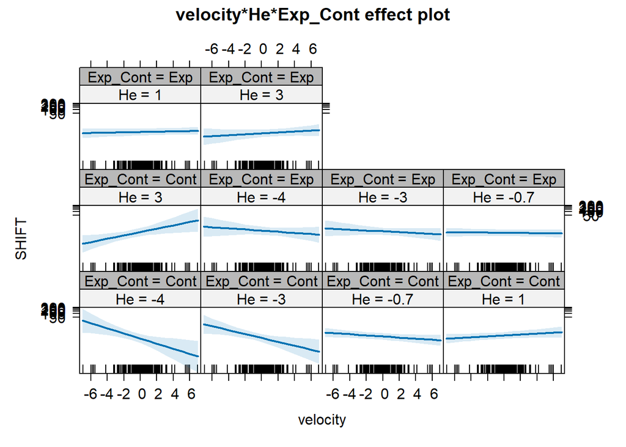

```r
plot(tmp$`velocity:He:Exp_Cont`)
```

```
## NOTE: He:Exp_Cont is not a high-order term in the model
```

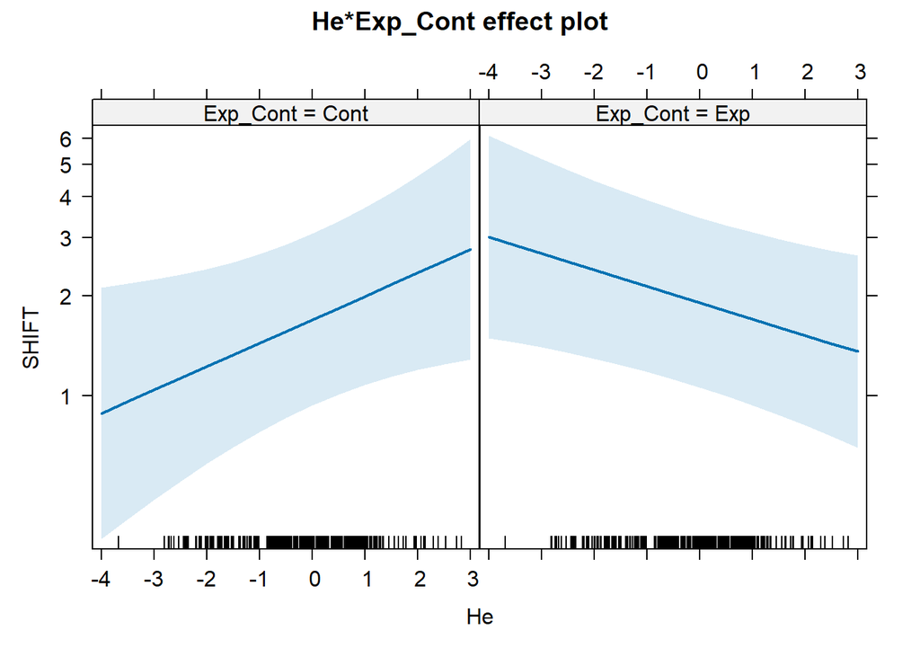

```r
plot(effect("He*Exp_Cont", bestmodel)) # He leads to faster contractions and slower expansions
```

```
## NOTE: velocity:He is not a high-order term in the model
```

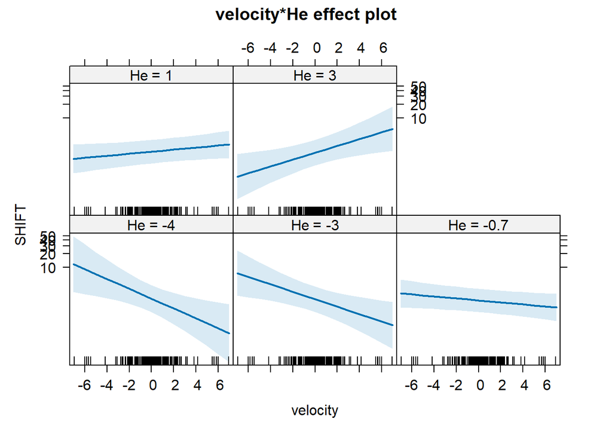

```r
plot(effect("velocity:He", bestmodel)) # He interacts with velocity to affect shift. Shift is larger when He is high and velocity is high. The isolated effect of He and velocity on Shift is not significant.
```

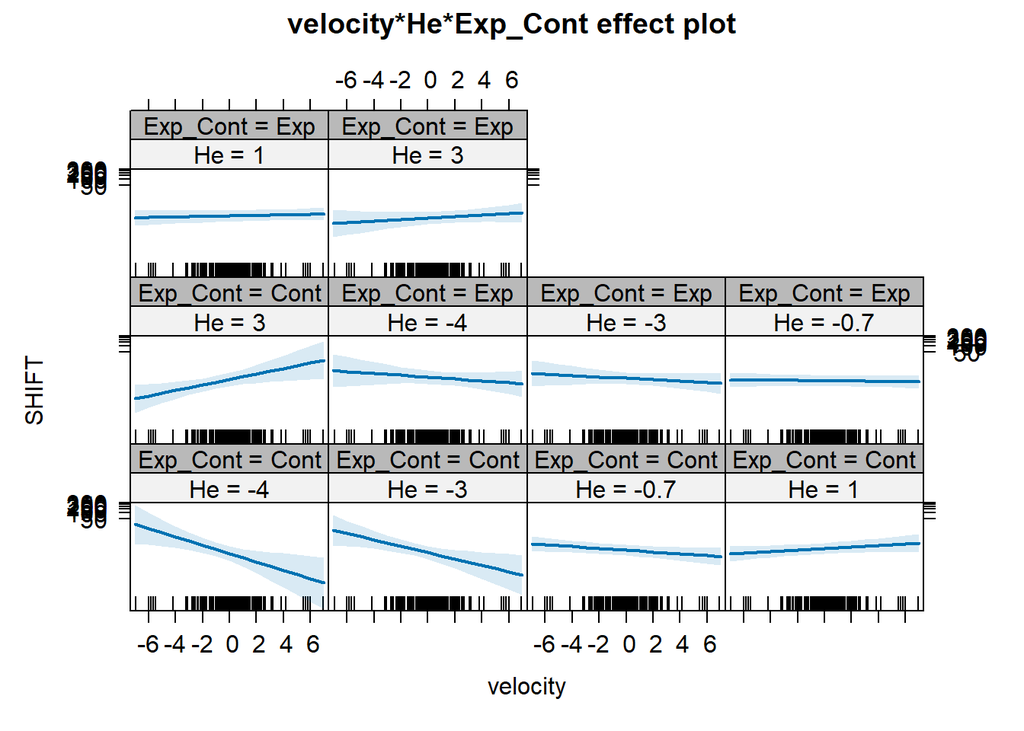

```r
plot(effect("velocity:He:Exp_Cont", bestmodel)) # Marginal effect >> When He is high, there are more contractions with increasing velocity. When He is low, there is less contractions with increasing velocities.
```

## 7.2 Code exp/cont II

This makes all velocities positive and changes the sign of shift when in the opposite direction of velocity. The shift now represents the expectation of shift relative to the velocity. Positive values represent shift is the same direction of velocity. Negative in the opposite direction.

```r
# Code expansion vs contraction
mydatatogo$Exp_Cont <- NA
mydatatogo$Exp_Cont[which(mydatatogo$Param == "LE" &
                              mydatatogo$SHIFT_raw >= 0  &
                              mydatatogo$velocity_raw > 0)] <- "Exp"
mydatatogo$Exp_Cont[which(mydatatogo$Param == "LE" &
                              mydatatogo$SHIFT_raw >= 0  &
                              mydatatogo$velocity_raw < 0)] <- "Cont"
mydatatogo$Exp_Cont[which(mydatatogo$Param == "LE" &
                              mydatatogo$SHIFT_raw <= 0  &
                              mydatatogo$velocity_raw > 0)] <- "Exp"
mydatatogo$Exp_Cont[which(mydatatogo$Param == "LE" &
                              mydatatogo$SHIFT_raw <= 0  &
                              mydatatogo$velocity_raw < 0)] <- "Cont"

mydatatogo$Exp_Cont[which(mydatatogo$Param == "TE" &
                              mydatatogo$SHIFT_raw >= 0  &
                              mydatatogo$velocity_raw > 0)] <- "Cont"
mydatatogo$Exp_Cont[which(mydatatogo$Param == "TE" &
                              mydatatogo$SHIFT_raw >= 0  &
                              mydatatogo$velocity_raw < 0)] <- "Exp"
mydatatogo$Exp_Cont[which(mydatatogo$Param == "TE" &
                              mydatatogo$SHIFT_raw <= 0  &
                              mydatatogo$velocity_raw > 0)] <- "Cont"
mydatatogo$Exp_Cont[which(mydatatogo$Param == "TE" &
                              mydatatogo$SHIFT_raw <= 0  &
                              mydatatogo$velocity_raw < 0)] <- "Exp"

mydatatogo$Exp_Cont[which(mydatatogo$Param == "O" &
                              mydatatogo$SHIFT_raw >= 0  &
                              mydatatogo$velocity_raw > 0)] <- "Exp"
mydatatogo$Exp_Cont[which(mydatatogo$Param == "O" &
                              mydatatogo$SHIFT_raw >= 0  &
                              mydatatogo$velocity_raw < 0)] <- "Cont"
mydatatogo$Exp_Cont[which(mydatatogo$Param == "O" &
                              mydatatogo$SHIFT_raw <= 0  &
                              mydatatogo$velocity_raw > 0)] <- "Cont"
mydatatogo$Exp_Cont[which(mydatatogo$Param == "O" &
                              mydatatogo$SHIFT_raw <= 0  &
                              mydatatogo$velocity_raw < 0)] <- "Exp"

# Fix shift & velocity sign
mydatatogo$SHIFTnew <- mydatatogo$SHIFT_raw
# mydatatogo$SHIFTnew <- mydatatogo$SHIFT_cor_raw
mydatatogo$velocitynew <- mydatatogo$velocity_raw

pos <- which(mydatatogo$velocity_raw <= 0)
mydatatogo$SHIFTnew[pos] <- mydatatogo$SHIFT_raw[pos] * -1
mydatatogo$velocitynew[pos] <- mydatatogo$velocity_raw[pos] * -1

summary(mydatatogo$SHIFTnew)
```

```
##     Min.  1st Qu.   Median     Mean  3rd Qu.     Max.
## -16.1721  -0.5588   0.2092   0.7282   1.8400  16.0211
```

```r
summary(mydatatogo$velocitynew)
```

```
##     Min.  1st Qu.   Median     Mean  3rd Qu.     Max.
## 0.009396 0.809005 1.477767 1.688156 2.304868 6.929532
```

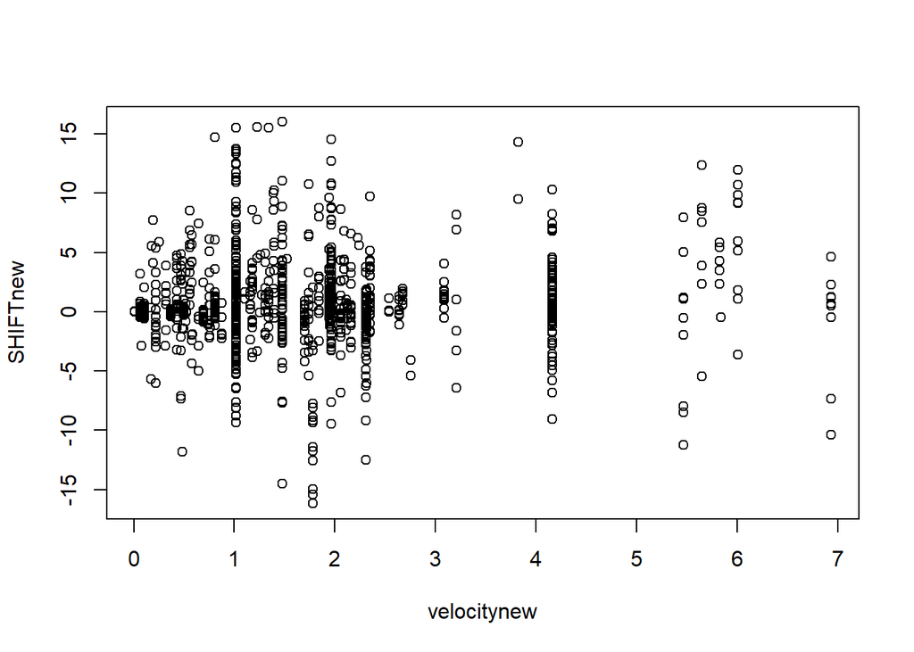

```r
plot(SHIFTnew~velocitynew,mydatatogo)
```

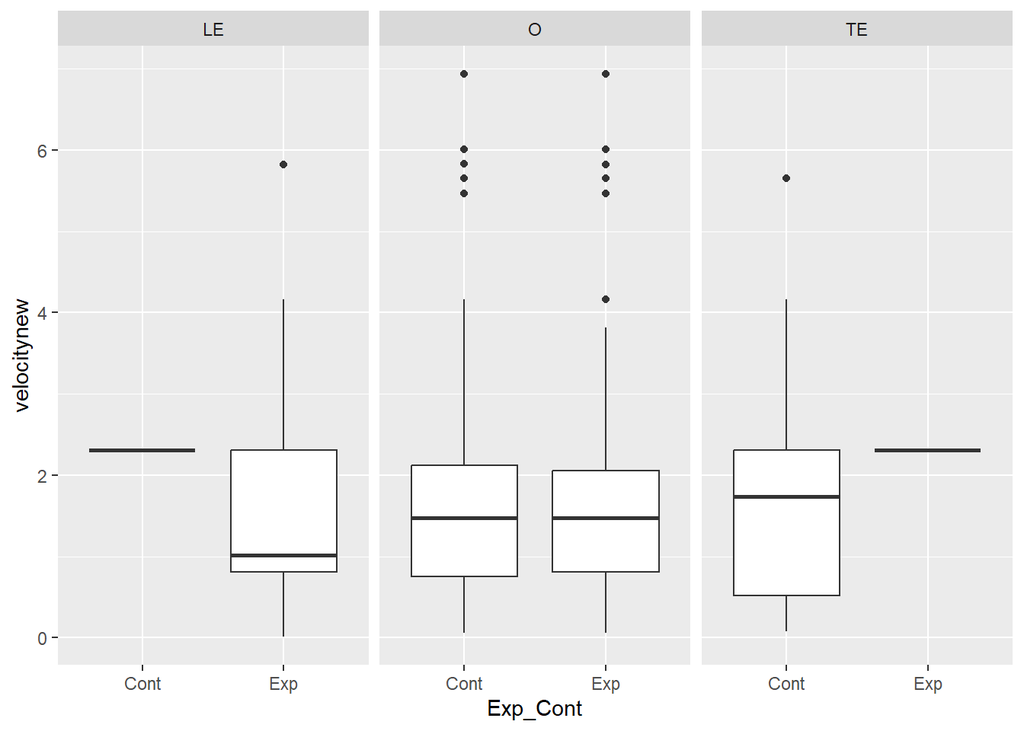

```r
ggplot(mydatatogo, aes(x = Exp_Cont, y = velocitynew))+
    geom_boxplot()+
    facet_wrap(.~Param)
```

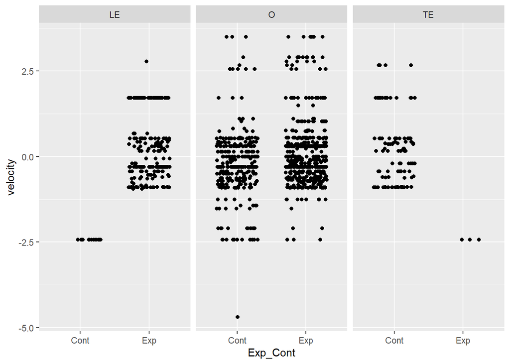

```r
ggplot(mydatatogo, aes(x = Exp_Cont, y = velocity))+
    geom_jitter(width = .3)+
    facet_wrap(.~Param)
```

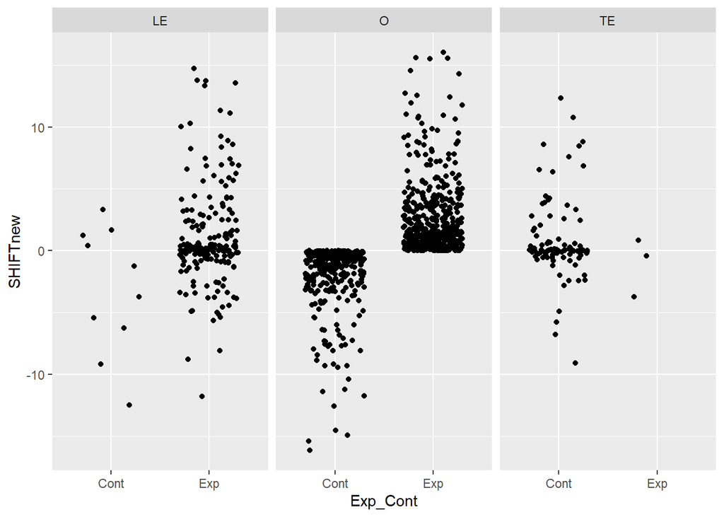

```r
ggplot(mydatatogo, aes(x = Exp_Cont, y = SHIFTnew))+
    geom_jitter(width = .3)+
    facet_wrap(.~Param)
```

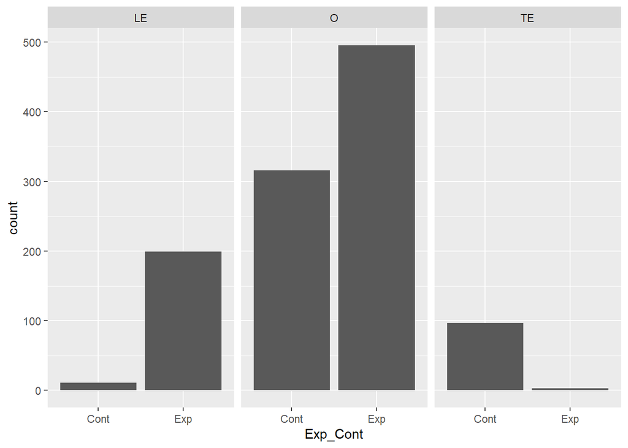

```r
ggplot(mydatatogo, aes(x = Exp_Cont))+
    geom_bar()+
    facet_wrap(.~Param)
```

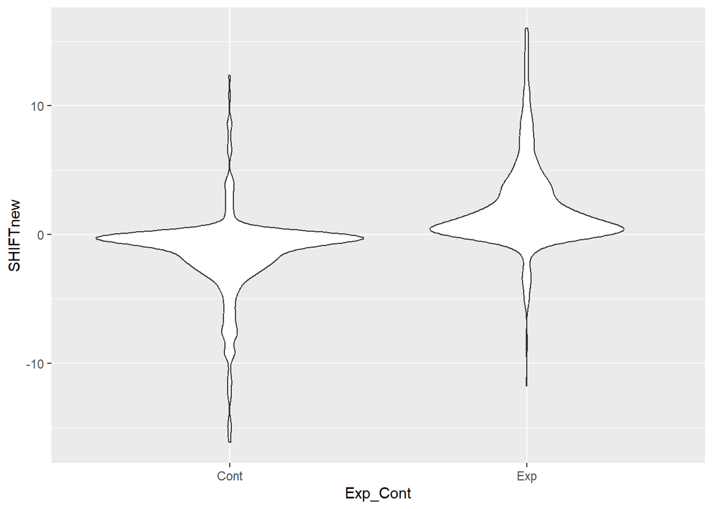

```r
ggplot(mydatatogo, aes(x = Exp_Cont, y = SHIFTnew))+
    geom_violin()
```

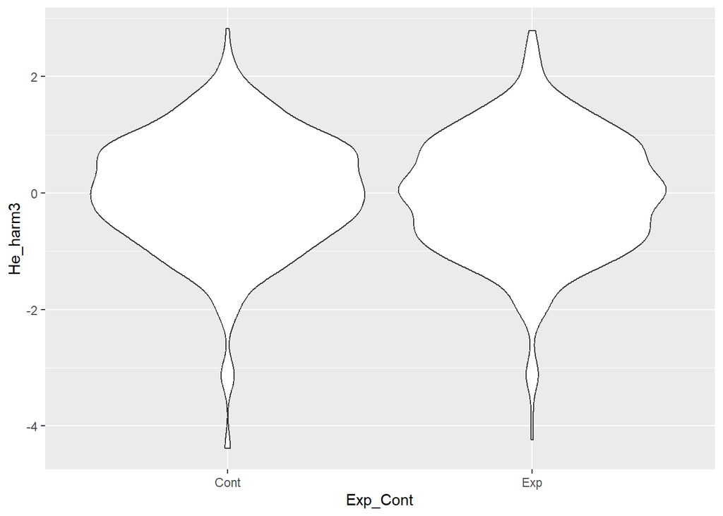

```r
ggplot(mydatatogo, aes(x = Exp_Cont, y = He_harm3))+
    geom_violin()
```

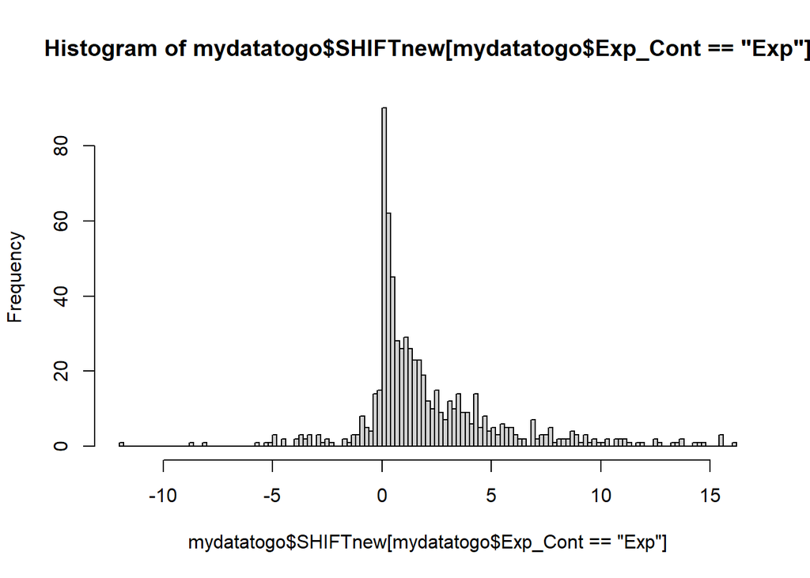

```r
hist(mydatatogo$SHIFTnew[mydatatogo$Exp_Cont=="Exp"],breaks = 100)
```

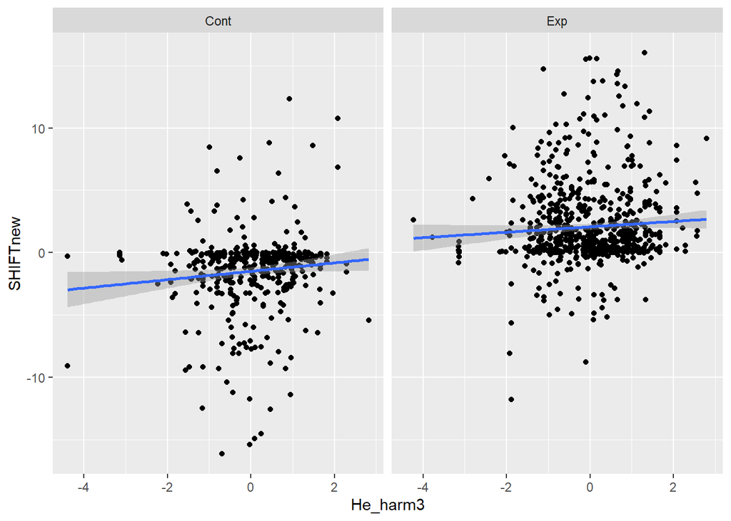

```r
ggplot(mydatatogo, aes(x = He_harm3, y = SHIFTnew))+
    geom_point()+
    facet_wrap(.~Exp_Cont)+
    geom_smooth(method='lm')
```